```python
import numpy as np
import pandas as pd
import matplotlib.pyplot as plt
import seaborn as sns
import arrow
from datetime import datetime
from sklearn.preprocessing import MinMaxScaler
from sklearn.model_selection import train_test_split
from sklearn.preprocessing import LabelEncoder
```

```python
df = pd.read_csv("KaggleV2-May-2016.csv") #reading the dataset and storing it inside pandas dataframe
```

```python
df.head() #seeing the first 5 rows of all the columns
```

|  | PatientId | AppointmentID | Gender | ScheduledDay | AppointmentDay | Age | Neighbourhood | Scholarship | Hipertension | Diabetes | Alcoholism | Handcap | SMS_received | No-show |
| --- | --- | --- | --- | --- | --- | --- | --- | --- | --- | --- | --- | --- | --- | --- |
| 0 | 2.987250e+13 | 5642903 | F | 2016-04-29T18:38:08Z | 2016-04-29T00:00:00Z | 62 | JARDIM DA PENHA | 0 | 1 | 0 | 0 | 0 | 0 | No |
| 1 | 5.589978e+14 | 5642503 | M | 2016-04-29T16:08:27Z | 2016-04-29T00:00:00Z | 56 | JARDIM DA PENHA | 0 | 0 | 0 | 0 | 0 | 0 | No |
| 2 | 4.262962e+12 | 5642549 | F | 2016-04-29T16:19:04Z | 2016-04-29T00:00:00Z | 62 | MATA DA PRAIA | 0 | 0 | 0 | 0 | 0 | 0 | No |
| 3 | 8.679512e+11 | 5642828 | F | 2016-04-29T17:29:31Z | 2016-04-29T00:00:00Z | 8 | PONTAL DE CAMBURI | 0 | 0 | 0 | 0 | 0 | 0 | No |
| 4 | 8.841186e+12 | 5642494 | F | 2016-04-29T16:07:23Z | 2016-04-29T00:00:00Z | 56 | JARDIM DA PENHA | 0 | 1 | 1 | 0 | 0 | 0 | No |

```python
df.columns #seeing the names of the column
```

```
Index(['PatientId', 'AppointmentID', 'Gender', 'ScheduledDay',
       'AppointmentDay', 'Age', 'Neighbourhood', 'Scholarship', 'Hipertension',
       'Diabetes', 'Alcoholism', 'Handcap', 'SMS_received', 'No-show'],
      dtype='object')
```

```python
df.describe() #seeing quantile records
```

|  | PatientId | AppointmentID | Age | Scholarship | Hipertension | Diabetes | Alcoholism | Handcap | SMS_received |
| --- | --- | --- | --- | --- | --- | --- | --- | --- | --- |
| count | 1.105270e+05 | 1.105270e+05 | 110527.000000 | 110527.000000 | 110527.000000 | 110527.000000 | 110527.000000 | 110527.000000 | 110527.000000 |
| mean | 1.474963e+14 | 5.675305e+06 | 37.088874 | 0.098266 | 0.197246 | 0.071865 | 0.030400 | 0.022248 | 0.321026 |
| std | 2.560949e+14 | 7.129575e+04 | 23.110205 | 0.297675 | 0.397921 | 0.258265 | 0.171686 | 0.161543 | 0.466873 |
| min | 3.921784e+04 | 5.030230e+06 | -1.000000 | 0.000000 | 0.000000 | 0.000000 | 0.000000 | 0.000000 | 0.000000 |
| 25% | 4.172614e+12 | 5.640286e+06 | 18.000000 | 0.000000 | 0.000000 | 0.000000 | 0.000000 | 0.000000 | 0.000000 |
| 50% | 3.173184e+13 | 5.680573e+06 | 37.000000 | 0.000000 | 0.000000 | 0.000000 | 0.000000 | 0.000000 | 0.000000 |
| 75% | 9.439172e+13 | 5.725524e+06 | 55.000000 | 0.000000 | 0.000000 | 0.000000 | 0.000000 | 0.000000 | 1.000000 |
| max | 9.999816e+14 | 5.790484e+06 | 115.000000 | 1.000000 | 1.000000 | 1.000000 | 1.000000 | 4.000000 | 1.000000 |

```python
df.info(null_counts=True) #seeing the datatypes along with if any data is null
```

```
<class 'pandas.core.frame.DataFrame'>
RangeIndex: 110527 entries, 0 to 110526
Data columns (total 14 columns):
 #   Column          Non-Null Count   Dtype
---  ------          --------------   -----
 0   PatientId       110527 non-null  float64
 1   AppointmentID   110527 non-null  int64
 2   Gender          110527 non-null  object
 3   ScheduledDay    110527 non-null  object
 4   AppointmentDay  110527 non-null  object
 5   Age             110527 non-null  int64
 6   Neighbourhood   110527 non-null  object
 7   Scholarship     110527 non-null  int64
 8   Hipertension    110527 non-null  int64
 9   Diabetes        110527 non-null  int64
 10  Alcoholism      110527 non-null  int64
 11  Handcap         110527 non-null  int64
 12  SMS_received    110527 non-null  int64
 13  No-show         110527 non-null  object
dtypes: float64(1), int64(8), object(5)
memory usage: 11.8+ MB
```

```
C:\Users\Arafat Ahmed\AppData\Local\Temp\ipykernel_5636\1845656048.py:1: FutureWarning: null_counts is deprecated. Use show_counts instead
  df.info(null_counts=True) #seeing the datatypes along with if any data is null
```

```python
df.isnull().sum() #seeing if any column contains empty value/null
```

```
PatientId         0
AppointmentID     0
Gender            0
ScheduledDay      0
AppointmentDay    0
Age               0
Neighbourhood     0
Scholarship       0
Hipertension      0
Diabetes          0
Alcoholism        0
Handcap           0
SMS_received      0
No-show           0
dtype: int64
```

As there are no empty values, then we are good with the dataset.

Now we are going to see the unique values in different columns

```python
for col in df.columns:
  print(col , np.unique(df[col]))
  print(df[col].value_counts())
```

```
PatientId [3.92178444e+04 4.37417565e+04 9.37795293e+04 ... 9.99946537e+14
 9.99968578e+14 9.99981632e+14]
8.221459e+14    88
9.963767e+10    84
2.688613e+13    70
3.353478e+13    65
6.264199e+12    62
                ..
8.622636e+11     1
9.267587e+12     1
5.764356e+12     1
5.712491e+12     1
1.557663e+13     1
Name: PatientId, Length: 62299, dtype: int64
AppointmentID [5030230 5122866 5134197 ... 5790466 5790481 5790484]
5642903    1
5692618    1
5687640    1
5740664    1
5740598    1
          ..
5718442    1
5426425    1
5424230    1
5720832    1
5629448    1
Name: AppointmentID, Length: 110527, dtype: int64
Gender ['F' 'M']
F    71840
M    38687
Name: Gender, dtype: int64
ScheduledDay ['2015-11-10T07:13:56Z' '2015-12-03T08:17:28Z' '2015-12-07T10:40:59Z' ...
 '2016-06-08T19:33:23Z' '2016-06-08T19:58:52Z' '2016-06-08T20:07:23Z']
2016-05-06T07:09:54Z    24
2016-05-06T07:09:53Z    23
2016-04-25T17:18:27Z    22
2016-04-25T17:17:46Z    22
2016-04-25T17:17:23Z    19
                        ..
2016-05-02T09:53:25Z     1
```

[output cut: 106 more lines]

```
Handcap [0 1 2 3 4]
0    108286
1      2042
2       183
3        13
4         3
Name: Handcap, dtype: int64
SMS_received [0 1]
0    75045
1    35482
Name: SMS_received, dtype: int64
No-show ['No' 'Yes']
No     88208
Yes    22319
Name: No-show, dtype: int64
```

we are going to drop PatientId and AppointmentID because it has no correlation with the output.

```python
df.drop(['PatientId', 'AppointmentID'], axis=1, inplace=True)
```

We are going to assign values by encoding Gender, No-show and Neighbourhood

```python
#'F' 'M' as 1 and 2
df['Gender'] = df['Gender'].map({'F':1, 'M':2})

#'No' 'Yes' as 0 and 1
df['No-show'] = df['No-show'].map({'No':0, 'Yes':1})
```

```python
gle = LabelEncoder()
neighbour_labels = gle.fit_transform(df['Neighbourhood'])
neighbour_mappings = {index: label for index, label in
                  enumerate(gle.classes_)}

neighbour_mappings
```

```
{0: 'AEROPORTO',
 1: 'ANDORINHAS',
 2: 'ANTÔNIO HONÓRIO',
 3: 'ARIOVALDO FAVALESSA',
 4: 'BARRO VERMELHO',
 5: 'BELA VISTA',
 6: 'BENTO FERREIRA',
 7: 'BOA VISTA',
 8: 'BONFIM',
 9: 'CARATOÍRA',
 10: 'CENTRO',
 11: 'COMDUSA',
 12: 'CONQUISTA',
 13: 'CONSOLAÇÃO',
 14: 'CRUZAMENTO',
```

[output cut: 66 more lines]

```python
df['NeighbourhoodLabel'] = neighbour_labels
df.head()
```

|  | Gender | ScheduledDay | AppointmentDay | Age | Neighbourhood | Scholarship | Hipertension | Diabetes | Alcoholism | Handcap | SMS_received | No-show | NeighbourhoodLabel |
| --- | --- | --- | --- | --- | --- | --- | --- | --- | --- | --- | --- | --- | --- |
| 0 | 1 | 2016-04-29T18:38:08Z | 2016-04-29T00:00:00Z | 62 | JARDIM DA PENHA | 0 | 1 | 0 | 0 | 0 | 0 | 0 | 39 |
| 1 | 2 | 2016-04-29T16:08:27Z | 2016-04-29T00:00:00Z | 56 | JARDIM DA PENHA | 0 | 0 | 0 | 0 | 0 | 0 | 0 | 39 |
| 2 | 1 | 2016-04-29T16:19:04Z | 2016-04-29T00:00:00Z | 62 | MATA DA PRAIA | 0 | 0 | 0 | 0 | 0 | 0 | 0 | 45 |
| 3 | 1 | 2016-04-29T17:29:31Z | 2016-04-29T00:00:00Z | 8 | PONTAL DE CAMBURI | 0 | 0 | 0 | 0 | 0 | 0 | 0 | 54 |
| 4 | 1 | 2016-04-29T16:07:23Z | 2016-04-29T00:00:00Z | 56 | JARDIM DA PENHA | 0 | 1 | 1 | 0 | 0 | 0 | 0 | 39 |

If we see in the dataset, No-Show is a categorical value, with Yes and No. So is SMS received, Handcap, Diabetes, Hipertension, Scholarship. Neighbourhood is based upon the areas of different names. Also, we will ignore the object and categorical columns, as we can see there is no outliers in those.

```
C:\Users\Arafat Ahmed\anaconda3\lib\site-packages\seaborn\_decorators.py:36: FutureWarning: Pass the following variable as a keyword arg: x. From version 0.12, the only valid positional argument will be `data`, and passing other arguments without an explicit keyword will result in an error or misint…
  warnings.warn(
```

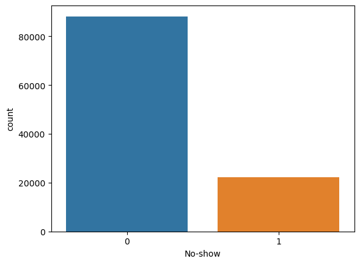

```python
sns.countplot('No-show',data=df)
```

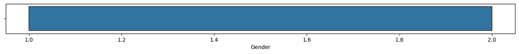

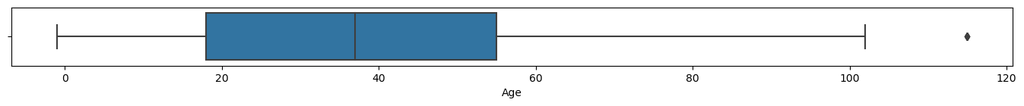

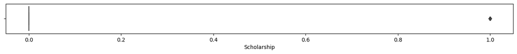

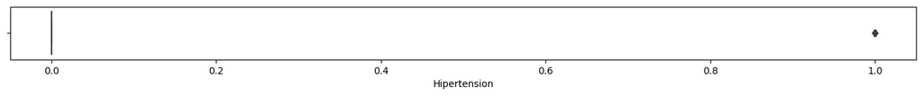

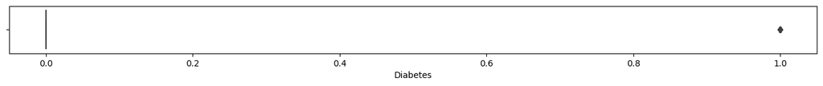

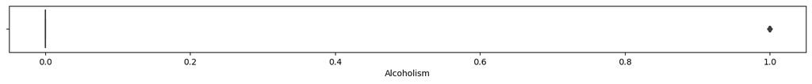

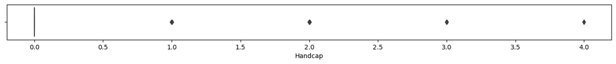

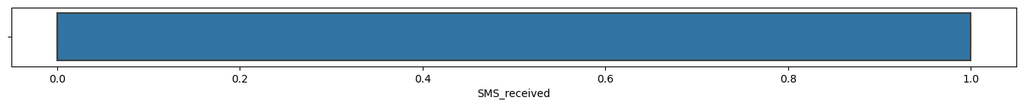

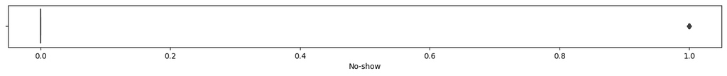

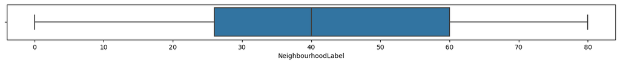

```python
df1=df.select_dtypes(exclude=['object'])

for column in df1:
        plt.figure(figsize=(17,1))
        sns.boxplot(data=df1, x=column)
```

```python
(df['Age']<0).value_counts()
```

```
False    110526
True          1
Name: Age, dtype: int64
```

```python
median = float(df['Age'].median())
df["Age"] = np.where(df["Age"] <0, median,df['Age'])
# df["Age"] = np.where(df["Age"] >105, median,df['Age'])

(df['Age']<0).value_counts()
```

```
False    110527
Name: Age, dtype: int64
```

Here, we will determine the awaiting time (AwaitingTime) which will be AppointmentDay - ScheduledDay, however, there are few issues with the dataset to begin with, let's explore that.

```python
df['ScheduledDay'] = pd.to_datetime(df['ScheduledDay'], #turning string to pandas datetime
 format = '%Y-%m-%dT%H:%M:%SZ',
 errors = 'coerce')
df['AppointmentDay'] = pd.to_datetime(df['AppointmentDay'],
 format = '%Y-%m-%dT%H:%M:%SZ',
 errors = 'coerce')
```

We are going to see that few values of scheduled is greater than Appoinment day

```python
(df['ScheduledDay'] > df['AppointmentDay']).sum()
```

```
38568
```

There are almost 40 thousand rows with Scheduled values greater than Appointment Day. This is because sometimes the appointment are made at the same day, and as time is not mentioned in AppointmentDay therefore, the values comes larger in Scheduled Day. To resolve this we will set AppointmentDay time to maximum and minus that by ScheduledDay.

```python
df['AppointmentDay'] = df['AppointmentDay'] + pd.Timedelta('1d') - pd.Timedelta('1s')
```

```python
(df['ScheduledDay'] > df['AppointmentDay']).sum()
```

```
5
```

As most of the negative values are taken out for AwaitingTime, we can see only 5 values exist, these can be regarded as outliers or mistakes in the datasets. Therefore, its best to remove them.

```python
len(df)
```

```
110527
```

```python
df = df.loc[(df['ScheduledDay'] <= df['AppointmentDay'])].copy()
```

```python
(df['ScheduledDay'] > df['AppointmentDay']).sum()
```

```
0
```

```python
len(df)
```

```
110522
```

As we can see 5 rows have been reduced from the dataset.

```python
a = df['AppointmentDay'][2] #testing out the process for calculating the awaiting time.
b = df['ScheduledDay'][2]

awaiting_time_seconds = (a - b).total_seconds()
print(awaiting_time_seconds)
```

```
27655.0
```

```python
awaiting_time = []
for row in range(len(df['AppointmentDay'])):
    a = df["AppointmentDay"].iloc[row]
    b = df['ScheduledDay'].iloc[row]
    awaiting_time_seconds = (a - b).total_seconds()
    awaiting_time.append(awaiting_time_seconds)

df['AwaitingTime'] = awaiting_time
```

```python
df.AwaitingTime.info() # created Awaiting time and stored it in total seconds.
```

```
<class 'pandas.core.series.Series'>
Int64Index: 110522 entries, 0 to 110526
Series name: AwaitingTime
Non-Null Count   Dtype
--------------   -----
110522 non-null  float64
dtypes: float64(1)
memory usage: 5.7 MB
```

Now we are going to break down the ScheduledDay and AppointmentDay yearwise, monthwise, weekwise, daywise, hourwise, minutewise and day of the week. This can help us create important features which can be related to the dataset, we might miss out.

```python
df['ScheduledDay_year'] = df['ScheduledDay'].dt.year
df['ScheduledDay_month'] = df['ScheduledDay'].dt.month
df['ScheduledDay_week'] = df['ScheduledDay'].dt.week
df['ScheduledDay_day'] = df['ScheduledDay'].dt.day
df['ScheduledDay_hour'] = df['ScheduledDay'].dt.hour
df['ScheduledDay_minute'] = df['ScheduledDay'].dt.minute
df['ScheduledDay_dayofweek'] = df['ScheduledDay'].dt.dayofweek

df['AppointmentDay_year'] = df['AppointmentDay'].dt.year
df['AppointmentDay_month'] = df['AppointmentDay'].dt.month
df['AppointmentDay_week'] = df['AppointmentDay'].dt.week
df['AppointmentDay_day'] = df['AppointmentDay'].dt.day
df['AppointmentDay_hour'] = df['AppointmentDay'].dt.hour
df['AppointmentDay_minute'] = df['AppointmentDay'].dt.minute
df['AppointmentDay_dayofweek'] = df['AppointmentDay'].dt.dayofweek
```

```
C:\Users\Arafat Ahmed\AppData\Local\Temp\ipykernel_5636\1507986140.py:3: FutureWarning: Series.dt.weekofyear and Series.dt.week have been deprecated. Please use Series.dt.isocalendar().week instead.
  df['ScheduledDay_week'] = df['ScheduledDay'].dt.week
C:\Users\Arafat Ahmed\AppData\Local\Temp\ipykernel_5636\1507986140.py:11: FutureWarning: Series.dt.weekofyear and Series.dt.week have been deprecated. Please use Series.dt.isocalendar().week instead.
  df['AppointmentDay_week'] = df['AppointmentDay'].dt.week
```

```python
df.head
```

[output not shown]

[output cut: 64 more lines]

All datetime features have been broken down into components.

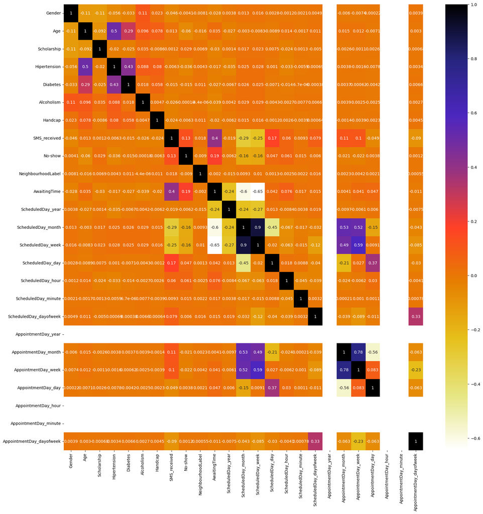

```python
#Using Pearson Correlation to see if the features are correlated
plt.figure(figsize=(20,20))
cor = df.corr()
sns.heatmap(cor, annot=True, cmap=plt.cm.CMRmap_r)
plt.show()
```

From the correlation plot we are only going to consider these features: 'SMS_received', 'AwaitingTime', 'ScheduledDay_month', 'ScheduledDay_week', as they seemed correlated with No-show. Others will not be taken into consideration for training and evaluating the model.

```python
scaler=MinMaxScaler((-1,1)) #normalizes the data which makes the model less bais
#transform only the awaiting time and age.
df[['Age', 'AwaitingTime']] = scaler.fit_transform(df[['Age', 'AwaitingTime']])
```

Min Max Normalization is done with the continuous variable so ensure that both data is scaled towards the same range.

```python
#getting the feature and labels
features=df[['SMS_received', 'AwaitingTime', 'ScheduledDay_month', 'ScheduledDay_week']]
target=df.loc[:,'No-show'].values
```

```python
X_train, X_test, y_train, y_test= train_test_split(features, target, test_size=0.3,random_state=0)#splitting data i
```

```python
X_train.shape,y_train.shape
```

```
((77365, 4), (77365,))
```

```python
X_test.shape,y_test.shape
```

```
((33157, 4), (33157,))
```

77 Thousand for training and 33 thousand for testing

```python
# Data Mining - classification- SVC, Prediction Check
from sklearn.svm import SVC
from sklearn.model_selection import train_test_split
from sklearn.metrics import confusion_matrix

svc_class = SVC()                                        # assign svc_class to the SVC function
svc_class.fit(X_train, y_train)                        # fit a SVC() model using 11,25 data points
print('svc_score = ', svc_class.score(X_test, y_test)) # score the SVC model base on 11,250 data points using the 3,750 data points
y_pred = svc_class.predict(X_test)                      # assigns y_pred to SVC prediction of X_test data
print(confusion_matrix(y_test, y_pred))                # displays correct on diagonal, typeI right, typeII left, all 3,750
```

```
svc_score =  0.7986850438821365
[[26482     0]
 [ 6675     0]]
```

In this SVC classification type I error is nil so the method could correctly identified the false positive and type II error are larger which indicates that this test could not identiefed true nageative values.

```python
# Data Mining - classification- K Nearest Neighbors Classifier
from sklearn.neighbors import KNeighborsClassifier, KNeighborsRegressor
from sklearn.model_selection import train_test_split
from sklearn.metrics import confusion_matrix

knn_class = KNeighborsClassifier()                       # assign knn_class to the KNeighborClassifier function
knn_class.fit(X_train, y_train)                        # fit a knn_class model using 77,365 data points
print('knn_class score = ', knn_class.score(X_test, y_test)) # score the knn_class model base on 77,365 data points using the 33,157 data points
y_pred = knn_class.predict(X_test)                      # assigns y_pred to knn_class prediction of X_test data
print(confusion_matrix(y_test, y_pred))                # displays correct on diagonal, typeI right, typeII left, all 33,157
```

```
C:\Users\Arafat Ahmed\anaconda3\lib\site-packages\sklearn\neighbors\_classification.py:228: FutureWarning: Unlike other reduction functions (e.g. `skew`, `kurtosis`), the default behavior of `mode` typically preserves the axis it acts along. In SciPy 1.11.0, this behavior will change: the default va…
  mode, _ = stats.mode(_y[neigh_ind, k], axis=1)
```

```
knn_class score =  0.7696112434779986
```

```
C:\Users\Arafat Ahmed\anaconda3\lib\site-packages\sklearn\neighbors\_classification.py:228: FutureWarning: Unlike other reduction functions (e.g. `skew`, `kurtosis`), the default behavior of `mode` typically preserves the axis it acts along. In SciPy 1.11.0, this behavior will change: the default va…
  mode, _ = stats.mode(_y[neigh_ind, k], axis=1)
```

```
[[24101  2381]
 [ 5258  1417]]
```

The KNN classifier result has both type I and type II error, that means this test is a better model for this data set in comparison to SVC classifier.

```python
# Data Mining - classification - Prediction (Logistic)
from sklearn.linear_model import LogisticRegression
from sklearn.model_selection import train_test_split
from sklearn.metrics import confusion_matrix

log = LogisticRegression()                                         # assigning alias lg to LogisticRegression() function
print(log.fit(X_train, y_train))              # displays R2 from 77,365 data points to train model
print(log.score(X_test, y_test))              # displays R2 from 33,157 data points used in 77,365 trained model
y_pred = log.predict(X_test)                  # assigns y_pred to prediction of X_test data
print(y_pred, np.array(y_test))              # displays y_pred versus y of test data set
print(confusion_matrix(y_test, y_pred))      # displays correct on diagonal, typeI right, typeII left, all 33,157
```

```
LogisticRegression()
0.7942214313719577
[0 0 0 ... 0 0 0] [0 0 0 ... 0 1 0]
[[26233   249]
 [ 6574   101]]
```

The logistic classfier has more type II error and less type I error than KNN classfier. Therefore it can also derived that for this inbalanced data set logistic classfier is not properly balanced model.

Basing on the requirment we have to choosee which model to use to find out the type I error or type II error accurately. For example if we had to find out the model which provides less type I error than possibly SVC is a better model for this data set. However if we had to choose a well balanced model than for this inbalanced data set KNN is better model.